[output not shown]

# Introduction

## Hierarchical time series

One of the consequences of increasing internet usage and life digitizing is increasing the amount of collected time series data. As an example we can refer to the Internet of Things (IoT) which produces huge amount of series in short period of time. Forecasting large collection of time series is always computationally heavy and challenging. In some cases these time series can be structured and disaggregated based on hierarchies or groups such as geographical location and gender. One example for hierarchical time series can be the amount of sales in restaurant chains which can be disaggregated into different branches and then foods or drinks. One visualizing example of these time series structure is shown in Figure @ref(fig:hierarchicalexample). In this example the hierarchy includes three levels. Top level, level 0, is the total series which is the aggregation of all the bottom level series, the middle level, level 1, series are aggregation of their own bottom level series for instance series A is the aggregation of AA and AB and finally the bottom level , level 2, series which includes the most disaggregated series.

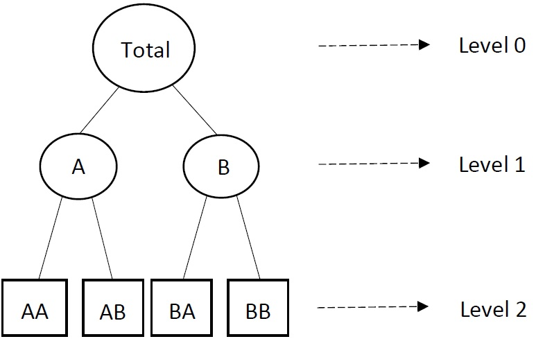

## Forecasting hierarchical and grouped time series

In hierarchy or grouped time series forecasting all the individual series can affect the accuracy level, since the most disaggregated or bottom level series are highly noisy and then their forecasting results are not that accurate and the most aggregated or total series, is smoother and less noisy though forecasting them is easier [@fliedner2001hierarchical]. On the other hand, we are ignoring hierarchy or grouping structure and there is no level structure in the forecasted series [@hyndman2016fast].Also, forecasting the most disaggregated level series and computing other level series by summing forecasts can result poor forecasts at higher level.

In literature there are some methods which consider hierarchy structure information in forecasting time series including top-down [@gross1990disaggregation], bottom-up [@kahn1998revisiting], middle-out and optimal combination [@hyndman2011optima] approaches. In top-down approach we first forecast the total series and then disaggregate the forecast to bottom level series based on a set of historical and forecasted proportions ( details about proportions in @athanasopoulos2009hierarchical). In bottom-up approach the forecasts in each level of hierarchy can be computed using aggregating the bottom-level series forecast. In middle-out approach, the process can be started from one of the middle levels and other forecasted can be computed using aggregation for upper levels and disaggregation for lower levels. Finally optimal combination uses all the base forecasts, forecasts for all the series in the whole hierarchy structure, then applies some regression models to reconcile those base forecasts. The advantage of the latest methods in compare with other methods is that it considers the interactions and correlation among the series in all the levels of hierarchy.

## Challenges and motivations

In 2014 @hyndman2014hts implemented a package called **hts** in R (@team2013r) for forecasting hierarchical time series including all the mentioned approaches in the last section. In this package two functions, *hts* and *gts*, produce hierarchical and grouped time series respectively. Inputs for these functions include most disaggregated or bottom-level series and hierarchy and group structure. In optimal combination method, there are two steps to determine the reconciled forecasts first forecasting all the bottom-level series and second reconciling those forecasts. Currently options for computing the bottom-level series forecasts are Random Walk (rw), Exponential Smoothing (ets), Autoregressive Integrated Moving Average (ARIMA).

When we encounter large collection of time series computing bottom-level forecasts using ets or ARIMA can be computationally heavy. In this research we are proposing a new linear function to calculate the bottom-level series forecasts fast which can compete ets and ARIMA.

# Proposed approach

$$\begin{equation}\label{eq:linearmodelexample}
y_t = \alpha_0 + \alpha_1 t + \beta_1 Season_{1t} + \beta_2 Season_{2t} + \cdots + \beta_m Season_{mt} + \gamma_1 y_{t-1} + \gamma_2 y_{t-2} + \cdots + \gamma_m y_{t-m} + \epsilon_{t}
\end{equation}$$

Where $y_t$ ($t=1,2,\ldots,T$) is the value of the series at time $t$, and $Season_j$ is a dummy variable taking value 1 if time $j$ is in season $j$ (e.g., for a daily time series with day-of-week seasonality, $j=7$). Further, $y_{t-j}$ is the $j$th lagged value.

The contribution in this research involves using equation @ref(eq:linearmodelexample) and optimal combination approach by @hyndman2011optima to adjust the computation challenge for large collection of time series.

# Applications

## Wikipedia pageview dataset

# Discussion and further research